# full_adf

## 🎯 Project Goal

This project implements an **event-driven, metadata-based Azure Data Factory pipeline**  
that automatically ingests, validates, routes, and transforms files stored in Azure Blob Storage.

The pipeline is triggered by **storage events** and dynamically decides how files should be processed  
based on **metadata and naming rules**. Only selected datasets (e.g. files starting with `"tita"`)  
are routed to transformation logic, ensuring data quality and efficient processing.

The main goal of the project was to demonstrate **cloud-native Data Engineering practices**:

- event-driven ETL orchestration
- metadata-driven pipeline design
- dynamic branching using ForEach & If Condition
- reusable, parameterized datasets
- scalable storage-only data pipelines

## 🧰 Technologies and Tools

| Category | Technology | Purpose |
| --- | --- | --- |
| Orchestration | **Azure Data Factory** | Pipeline orchestration |
| Automation | **Storage Event Trigger** | Automatic pipeline execution |
| Storage | **Azure Data Lake Storage Gen2 (ADLS Gen2)** | Source, staging & curated layers |
| Control Flow | Get Metadata, ForEach, If Condition | Dynamic routing logic |
| Processing | **ADF Mapping Data Flow** | Data transformation |
| Architecture | Event-driven, metadata-based | Scalable cloud ETL |

## 🏗️ Architecture Overview

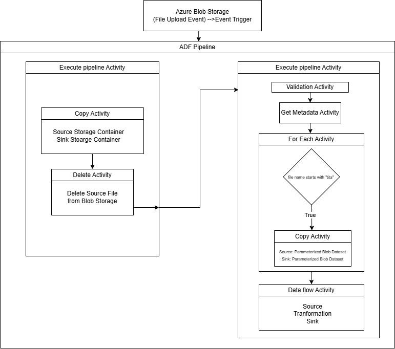

This architecture ensures **fully automated, reliable, and scalable ingestion**.

## 🔄 Master Pipeline – Event-Driven Orchestration

[figure not shown]

The master pipeline is executed automatically via a **storage event trigger**  
and coordinates the entire workflow.

This guarantees **idempotent and hands-free processing**.

## 🔁 Executed Pipeline – Metadata-Driven Logic

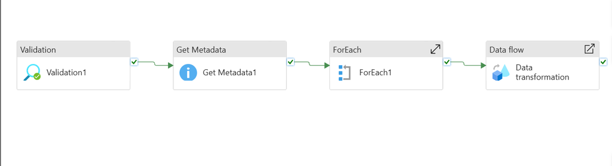

The executed pipeline contains the core dynamic logic.

### Processing steps:

- **Get Metadata** – reads file name and attributes
- **ForEach Activity** – iterates over detected files
- **If Condition** – applies naming-based logic

## 🔀 Conditional Routing – If Activity

Files that start with `"tita"` are processed further,  
while non-matching files are skipped or handled separately.

This prevents unnecessary processing and enforces data quality rules.

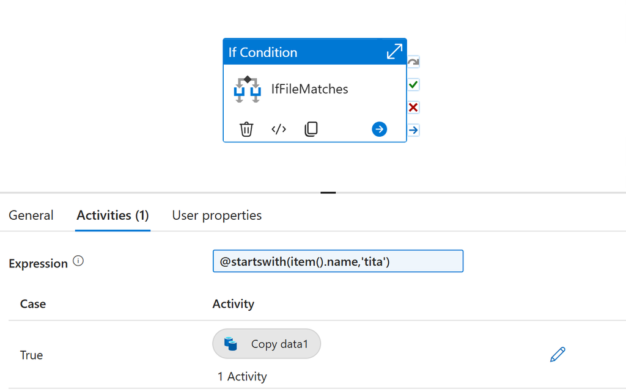

## 📦 Parameterized Datasets

All datasets are fully parameterized, enabling:

- dynamic source paths
- dynamic sink locations
- reuse across pipelines
- easy extension to new datasets

This design significantly improves maintainability and scalability.

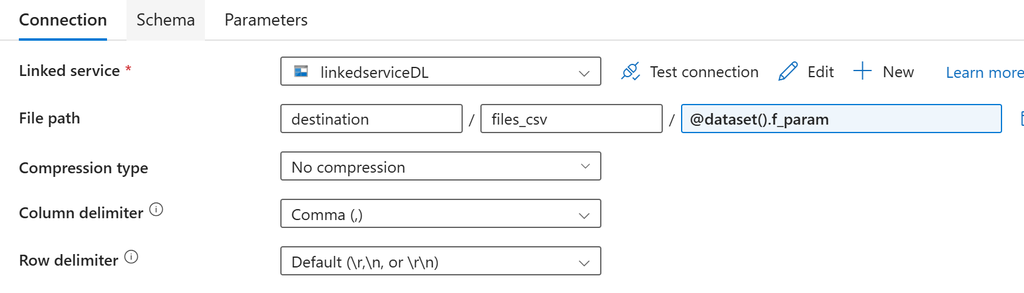

## 🔄 Data Transformation – Mapping Data Flow

Selected files are transformed using **ADF Mapping Data Flows**, where data is:

- transformed according to business rules
- written back to curated storage layers

Transformation logic is fully decoupled from orchestration.

## 🧠 Key Design Highlights

- Event-driven pipeline execution
- Metadata-based routing logic
- Dynamic branching using **ForEach & If Condition**
- Storage-only, cloud-native architecture
- Reusable datasets and dataflows
- Safe processing with post-success cleanup

## 🚀 Possible Enhancements

- Add schema validation rules
- Introduce logging & monitoring storage
- Add alerting for failed executions
- Extend conditional logic for additional file types
- Optimize parallel processing for large batches

## 🧠 What I Learned

- Designing event-driven Azure Data Factory pipelines
- Implementing metadata-driven ETL logic
- Building dynamic, reusable ADF components
- Applying cloud-native Data Engineering best practices
- Creating scalable and maintainable data workflows